# Data Visualization in Python

- Mengshu Liu
- 9/28/2019

## 1. The Science behind Visualizations

## 2. The Types of Visualizations

## 3. The Types of Data

## 4. Why Python

## 5. Coding Visualization in Python

## 1. The Science behind Visualizations

### 1.1 Why Do We Visualize Data?

- The Anscombe's quartet

[figure not shown]

### 1.1 Why Do We Visualize Data?

- The Anscombe's quartet

[figure not shown]

### 1.1 Why Do We Visualize Data?

- The Datasaurus Dozen

[figure not shown]

- The Hawks Game

[figure not shown]

- The Hawks Game

[figure not shown]

- The Infant Books

[figure not shown]

- The Harry Potter Books

[figure not shown]

- How many 9 in the figure?

[figure not shown]

- How many 9 in the figure?

[figure not shown]

### 1.2 How Do We Visualize Data

- Preattentive Attributes

[figure not shown]

## The Types of Visualizations

[figure not shown]

## The Types of Data

[figure not shown]

## The Products of Visualization

[figure not shown]

## Coding Visualization in Python

- Easy to use
- Low cost
- Reproducible
- Versatile

### Python Visualization Landscape

[figure not shown]

### Matplotlib

- Matplotlib is the "grandfather" library of data visualization with Python.
- It is an excellent 2D and 3D graphics library for generating scientific figures.
- Some of the major Pros of Matplotlib are:
  - Generally easy to get started for simple plots
  - Support for custom labels and texts
  - Great control of every element in a figure
  - High-quality output in many formats
  - Very customizable in general

```python
import matplotlib.pyplot as plt
%matplotlib inline

import numpy as np
x = np.linspace(0, 5, 11)
y = x ** 2
```

```python
x
```

```
array([0. , 0.5, 1. , 1.5, 2. , 2.5, 3. , 3.5, 4. , 4.5, 5. ])
```

```python
y
```

```
array([ 0.  ,  0.25,  1.  ,  2.25,  4.  ,  6.25,  9.  , 12.25, 16.  ,
       20.25, 25.  ])
```

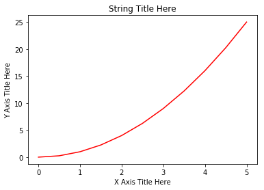

```python
plt.plot(x, y, 'r') # 'r' is the color red
plt.xlabel('X Axis Title Here')
plt.ylabel('Y Axis Title Here')
plt.title('String Title Here')
plt.show()
```

```python
fig.savefig("filename.png")
```

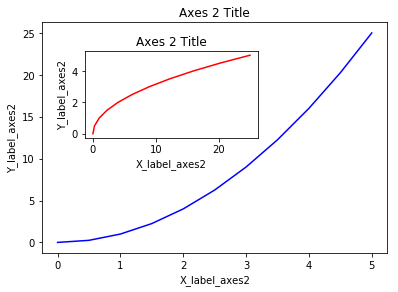

```python
# Creates blank canvas
fig = plt.figure()

axes1 = fig.add_axes([0.1, 0.1, 0.8, 0.8]) # main axes
axes2 = fig.add_axes([0.2, 0.5, 0.4, 0.3]) # inset axes

# Larger Figure Axes 1
axes1.plot(x, y, 'b')
axes1.set_xlabel('X_label_axes2')
axes1.set_ylabel('Y_label_axes2')
axes1.set_title('Axes 2 Title')

# Insert Figure Axes 2
axes2.plot(y, x, 'r')
axes2.set_xlabel('X_label_axes2')
axes2.set_ylabel('Y_label_axes2')
axes2.set_title('Axes 2 Title');
```

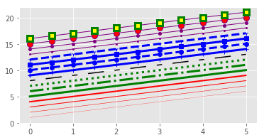

```python
fig, ax = plt.subplots(figsize=(6,3))
ax.plot(x, x+1, color="red", linewidth=0.25)
ax.plot(x, x+2, color="red", linewidth=0.50)
ax.plot(x, x+3, color="red", linewidth=1.00)
ax.plot(x, x+4, color="red", linewidth=2.00)
# possible linestype options ‘-‘, ‘–’, ‘-.’, ‘:’, ‘steps’
ax.plot(x, x+5, color="green", lw=3, linestyle='-')
ax.plot(x, x+6, color="green", lw=3, ls='-.')
ax.plot(x, x+7, color="green", lw=3, ls=':')
# custom dash
line, = ax.plot(x, x+8, color="black", lw=1.50)
line.set_dashes([5, 10, 15, 10]) # format: line length, space length, ...
# possible marker symbols: marker = '+', 'o', '*', 's', ',', '.', '1', '2', '3', '4', ...
ax.plot(x, x+ 9, color="blue", lw=3, ls='-', marker='+')
ax.plot(x, x+10, color="blue", lw=3, ls='--', marker='o')
ax.plot(x, x+11, color="blue", lw=3, ls='-', marker='s')
ax.plot(x, x+12, color="blue", lw=3, ls='--', marker='1')
# marker size and color
ax.plot(x, x+13, color="purple", lw=1, ls='-', marker='o', markersize=2)
ax.plot(x, x+14, color="purple", lw=1, ls='-', marker='o', markersize=4)
ax.plot(x, x+15, color="purple", lw=1, ls='-', marker='o', markersize=8, markerfacecolor="red")
ax.plot(x, x+16, color="purple", lw=1, ls='-', marker='s', markersize=8, markerfacecolor="yellow", markeredgewidth=3, markeredgecolor="green");
```

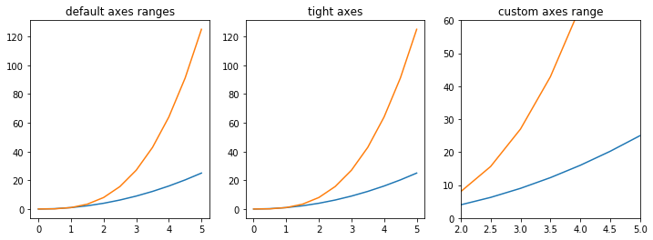

```python
fig, axes = plt.subplots(1, 3, figsize=(12, 4))

axes[0].plot(x, x**2, x, x**3)
axes[0].set_title("default axes ranges")

axes[1].plot(x, x**2, x, x**3)
axes[1].axis('tight')
axes[1].set_title("tight axes")

axes[2].plot(x, x**2, x, x**3)
axes[2].set_ylim([0, 60])
axes[2].set_xlim([2, 5])
axes[2].set_title("custom axes range");
```

### Pandas

#### Plot Types

There are several plot types built-in to pandas, most of them statistical plots by nature:

- df.plot.area
- df.plot.barh
- df.plot.density
- df.plot.hist
- df.plot.line
- df.plot.scatter
- df.plot.bar
- df.plot.box
- df.plot.hexbin
- df.plot.kde
- df.plot.pie

You can also just call df.plot(kind='hist') or replace that kind argument with any of the key terms shown in the list above (e.g. 'box','barh', etc..)

```python
import pandas as pd
df1 = pd.read_csv('df1',index_col=0)
df2 = pd.read_csv('df2')
```

```python
import matplotlib.pyplot as plt
plt.style.use('ggplot')
```

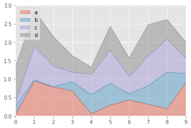

```python
df2.plot.area(alpha=0.4)
```

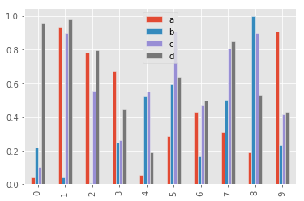

```python
df2.plot.bar()
```

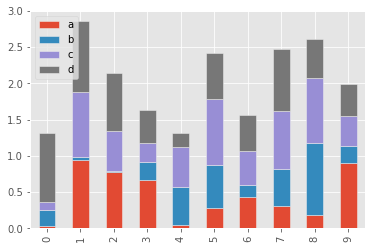

```python
df2.plot.bar(stacked=True)
```

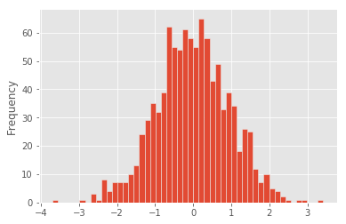

```python
df1['A'].plot.hist(bins=50)
```

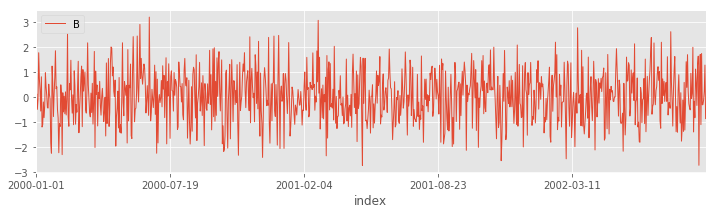

```python
df1.reset_index().plot.line(x='index',y='B',figsize=(12,3),lw=1)
```

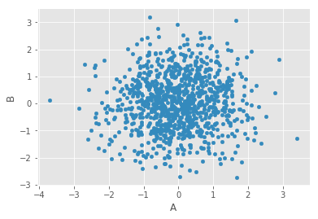

```python
df1.plot.scatter(x='A',y='B')
```

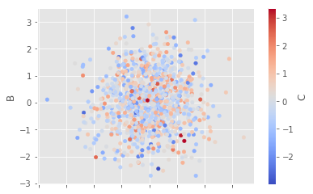

```python
df1.plot.scatter(x='A',y='B',c='C',cmap='coolwarm')
```

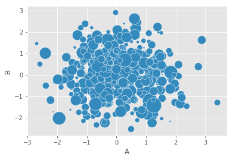

```python
df1.plot.scatter(x='A',y='B',s=df1['C']*200, edgecolor="w")
```

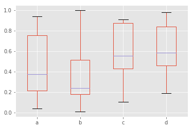

```python
df2.plot.box()
```

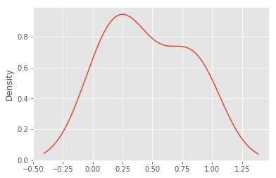

```python
df2['a'].plot.kde()
```

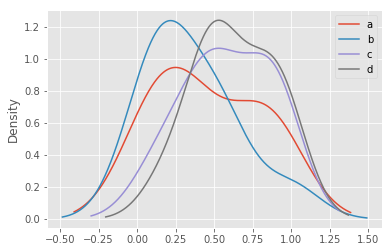

```python
df2.plot.density()
```

### Seaborn

- Seaborn is a Python data visualization library based on matplotlib.
- It provides a high-level interface for drawing attractive and informative statistical graphics.

### Categorical Data Plots

- boxplot
- violinplot
- stripplot
- swarmplot
- barplot
- countplot

```python
import seaborn as sns
tips = sns.load_dataset('tips')
tips.head()
```

|  | total_bill | tip | sex | smoker | day | time | size |
| --- | --- | --- | --- | --- | --- | --- | --- |
| 0 | 16.99 | 1.01 | Female | No | Sun | Dinner | 2 |
| 1 | 10.34 | 1.66 | Male | No | Sun | Dinner | 3 |
| 2 | 21.01 | 3.50 | Male | No | Sun | Dinner | 3 |
| 3 | 23.68 | 3.31 | Male | No | Sun | Dinner | 2 |
| 4 | 24.59 | 3.61 | Female | No | Sun | Dinner | 4 |

## barplot and countplot

These very similar plots allow you to get aggregate data off a categorical feature in your data. **barplot** is a general plot that allows you to aggregate the categorical data based off some function, by default the mean:

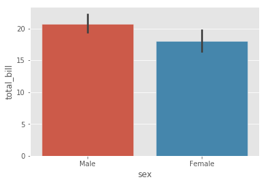

```python
sns.barplot(x='sex',y='total_bill',data=tips)
```

You can change the estimator object to your own function, that converts a vector to a scalar:

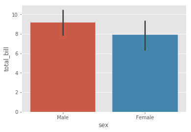

```python
sns.barplot(x='sex',y='total_bill',data=tips,estimator=np.std)
```

### countplot

This is essentially the same as barplot except the estimator is explicitly counting the number of occurrences. Which is why we only pass the x value:

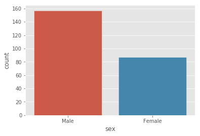

```python
sns.countplot(x='sex',data=tips)
```

## boxplot and violinplot

boxplots and violinplots are used to shown the distribution of categorical data. A box plot (or box-and-whisker plot) shows the distribution of quantitative data in a way that facilitates comparisons between variables or across levels of a categorical variable. The box shows the quartiles of the dataset while the whiskers extend to show the rest of the distribution, except for points that are determined to be “outliers” using a method that is a function of the inter-quartile range.

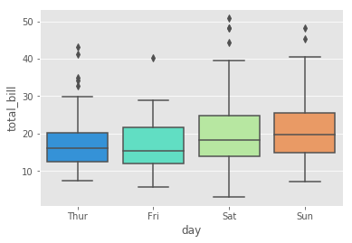

```python
sns.boxplot(x="day", y="total_bill", data=tips,palette='rainbow')
```

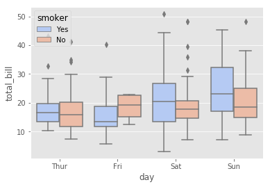

```python
sns.boxplot(x="day", y="total_bill", hue="smoker",data=tips, palette="coolwarm")
```

### violinplot

A violin plot plays a similar role as a box and whisker plot. It shows the distribution of quantitative data across several levels of one (or more) categorical variables such that those distributions can be compared. Unlike a box plot, in which all of the plot components correspond to actual datapoints, the violin plot features a kernel density estimation of the underlying distribution.

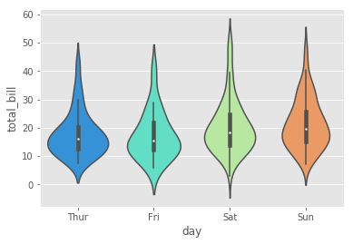

```python
sns.violinplot(x="day", y="total_bill", data=tips,palette='rainbow')
```

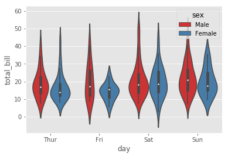

```python
sns.violinplot(x="day", y="total_bill", data=tips,hue='sex',palette='Set1')
```

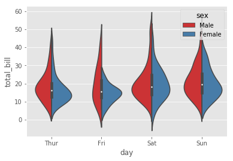

```python
sns.violinplot(x="day", y="total_bill", data=tips,hue='sex',split=True,palette='Set1')
```

## stripplot and swarmplot

The stripplot will draw a scatterplot where one variable is categorical. A strip plot can be drawn on its own, but it is also a good complement to a box or violin plot in cases where you want to show all observations along with some representation of the underlying distribution.

The swarmplot is similar to stripplot(), but the points are adjusted (only along the categorical axis) so that they don’t overlap. This gives a better representation of the distribution of values, although it does not scale as well to large numbers of observations (both in terms of the ability to show all the points and in terms of the computation needed to arrange them).

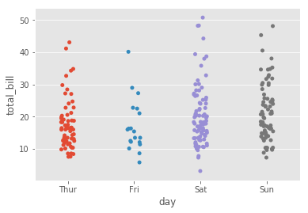

```python
sns.stripplot(x="day", y="total_bill", data=tips)
```

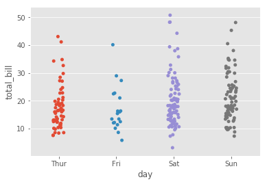

```python
sns.stripplot(x="day", y="total_bill", data=tips,jitter=True)
```

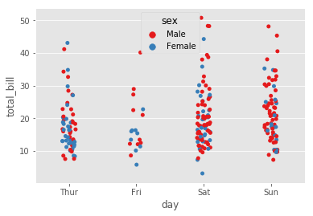

```python
sns.stripplot(x="day", y="total_bill", data=tips,jitter=True,hue='sex',palette='Set1')
```

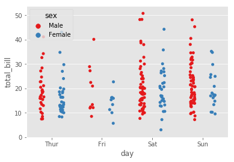

```python
sns.stripplot(x="day", y="total_bill", data=tips, jitter=True,hue='sex',palette='Set1',dodge=True)
```

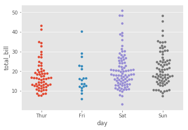

```python
sns.swarmplot(x="day", y="total_bill", data=tips)
```

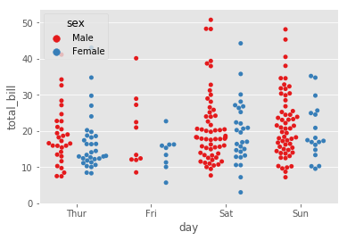

```python
sns.swarmplot(x="day", y="total_bill",hue='sex',data=tips, palette="Set1", dodge=True)
```

### Combining Categorical Plots

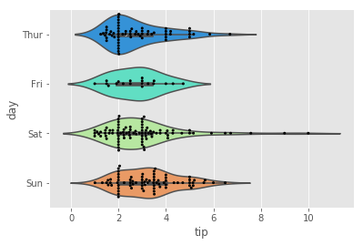

```python
sns.violinplot(x="tip", y="day", data=tips,palette='rainbow')
sns.swarmplot(x="tip", y="day", data=tips,color='black',size=3)
```

## Distribution Plots

- distplot
- jointplot
- pairplot
- rugplot
- kdeplot

```python
import seaborn as sns
plt.rcParams["patch.force_edgecolor"] = True
sns.set_palette('Set1')
tips = sns.load_dataset('tips')
tips.head()
```

|  | total_bill | tip | sex | smoker | day | time | size |
| --- | --- | --- | --- | --- | --- | --- | --- |
| 0 | 16.99 | 1.01 | Female | No | Sun | Dinner | 2 |
| 1 | 10.34 | 1.66 | Male | No | Sun | Dinner | 3 |
| 2 | 21.01 | 3.50 | Male | No | Sun | Dinner | 3 |
| 3 | 23.68 | 3.31 | Male | No | Sun | Dinner | 2 |
| 4 | 24.59 | 3.61 | Female | No | Sun | Dinner | 4 |

## distplot

The distplot shows the distribution of a univariate set of observations.

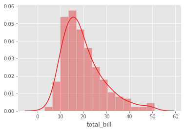

```python
sns.distplot(tips['total_bill'])
# Safe to ignore warnings
```

To remove the kde layer and just have the histogram use:

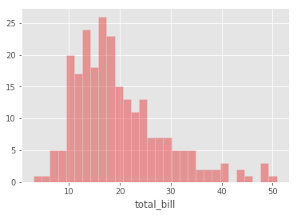

```python
sns.distplot(tips['total_bill'],kde=False,bins=30)
```